# Interactive Shiny App: Ecological footprints by Coutry and by Year

2021-12-20

## Context

- Rise in ecological concerns
- World leaders meetings to bring that topic further and take measures
- Heavy political discussions and debates dividing the population

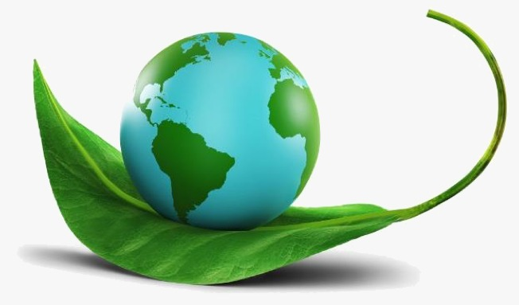

## Agenda

- Identified pain points
- Goals and Impact
- Data
- Sustainability App
- Limitations &Learnings
- Conclusion

## Identfied pain points

- **Uneducated population:** Many aspects of sustainability are not well understood
- **Lack of transparency:** Not immediately obvious how our personal immediate actions fit the overall picture
- **Scattered data:** Sustainability data is scattered among all kinds of media in a “fuzzy” way.

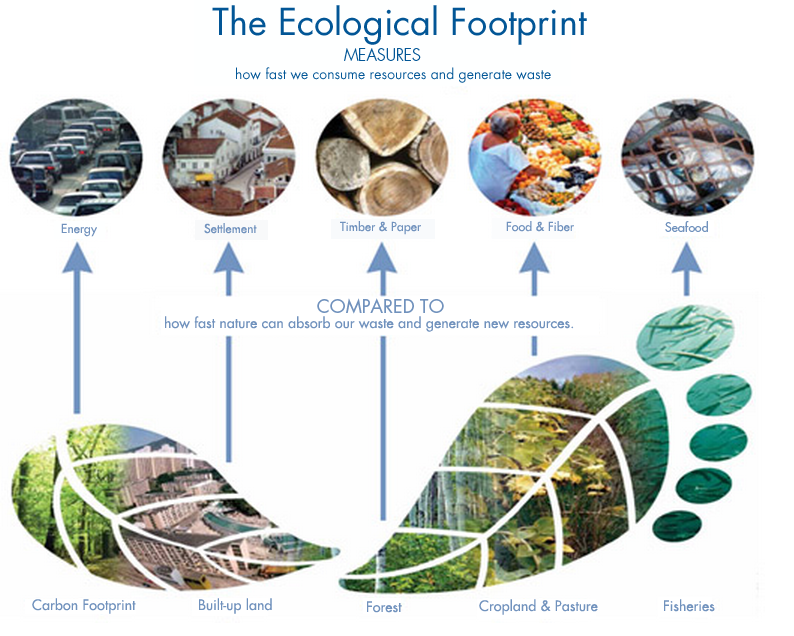

## Goals

To address the above points and challenges, we want to create the S(ust)hinybility app based on a reliable database. This app

- **gathers** worldwide data on carbon emissions
- **exploits** the specific information by year and by country
- **provides** visualization to compare carbon emissions on a country (or region) level

## Impact

**First:** the individuals are nudged to learn

**Second:** making ecological footprints comparable

**Third:** the interactive app helps to check facts and used against wrongly spread information

- Increases knowledge and awareness
- Higher satisfaction of researchers
- This increases data credibility

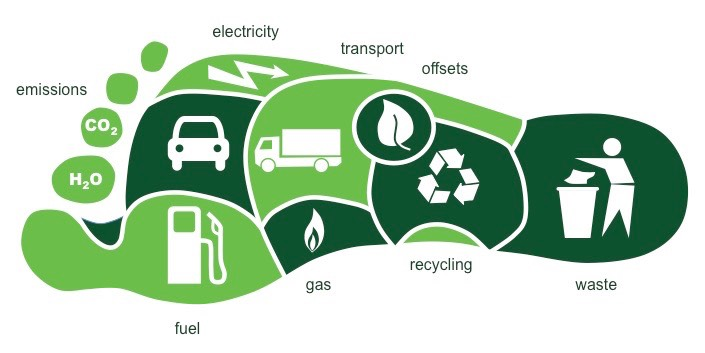

## Data

- *Source:* 2019 edition of the *National Footprint and Biocapacity Accounts*
- *Variables:* The (public) data set has 12 variables and provide information on 72,186 observations on 192 countries
- *Time frame:* 1961 - 2016

## Important terms

- **Ecological Footprint**
- **Biocapacity**
- **Carbon Footprint**

## Sustshinability App

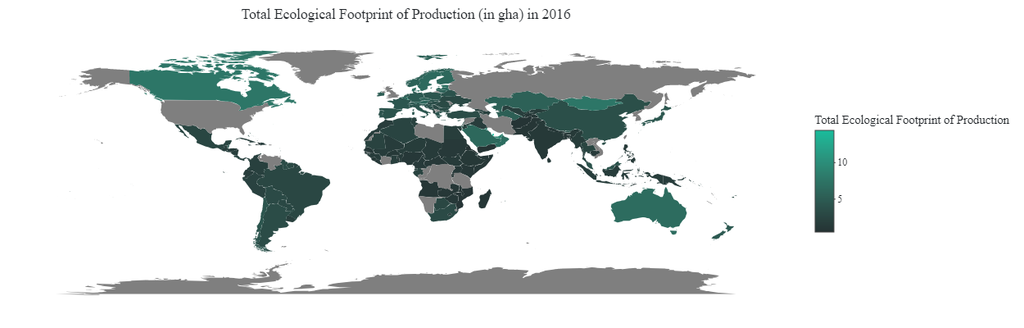

World Map Overview

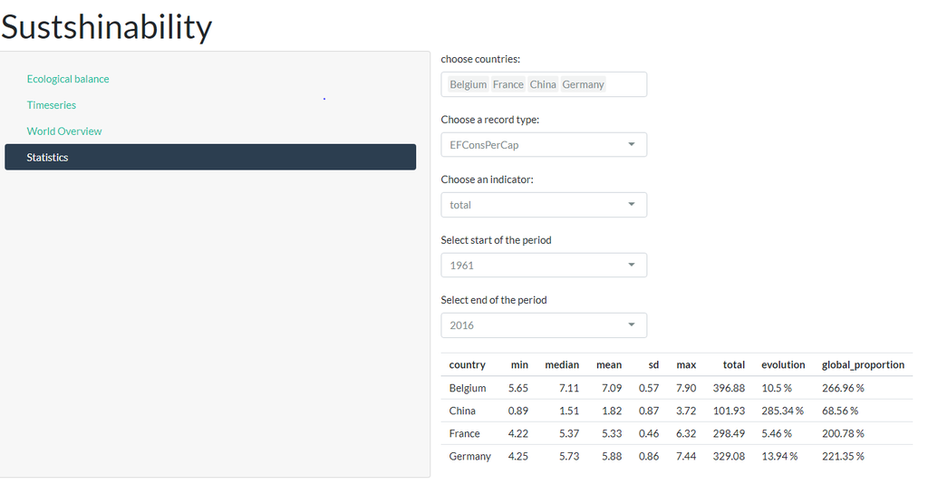

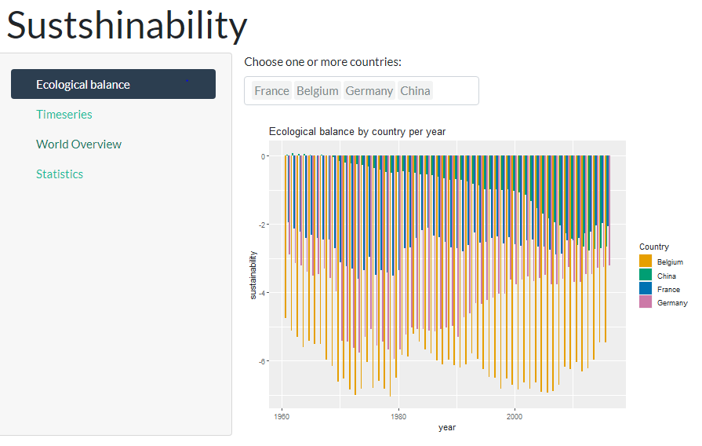

## Time Series (4)

[figure not shown]

Time Series FR, BEL, GER, CH.

## Website

[figure not shown]

## Limitations

- **Project management:** Starting ideas too optimistic and not realistic for timeframe of class schedule
- **Data:** Generality of dataset, understanding of data and selection bias
- **Covid-19:** Lost unnecessary time due to remote working

## Learnings

- **(1)** Conversion of ideas into code is time consuming (and fixing errors or deleting websites)
- **(2)** GitHUb is quite useful for group projects and time-saving
- **(3)** The bottlenecks of projects are usually fixing errors and checking the package
- **(4)** To-Do lists and Github Projects help to track progress and have a clear view of the project

## Conclusion

Improvements for package :

- Reduce the data size and computational time
- More complex shiny app

We achieved our goals ! :

- We managed to exploits these information to provide educational content for peoples
- Visualization is created thanks to our shiny app
- We gathered a torough database

## Thank you for your attention

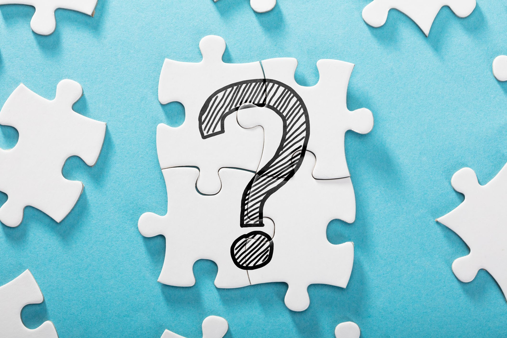